# Social Care Survey Open Data

Import and Wrangle

# 1 Introduction

This is a first look at open data provided by the Scottish Government. The data is anonymised at the individual level for home care data collected in 2010, 2011, & 2012 and can be downloaded here:-

```r
library(dplyr)
library(mice)
library(VIM)
```

# 2 Import the data

I have saved the files in the working directory - Need to import them into memory.

```r
hmcare2010 <- read.csv("2010.csv")
hmcare2011 <- read.csv("2011.csv")
hmcare2012 <- read.csv("2012.csv")
```

# 3 Descriptives

## 3.1 First look at each file.

```r
glimpse(hmcare2010)
```

```
## Observations: 76,202
## Variables: 19
## $ LAcode            <int> 100, 100, 100, 100, 100, 100, 100, 100, 100,...
## $ clientID          <fctr> ZZXJX, VLKT8, 418H1, 7SF1N, TKCFN, 5EFK3, D...
## $ AgeGRP            <int> 5, 4, 3, 4, 3, 3, 3, 3, 3, 5, 1, 4, 3, 4, 3,...
## $ ClientGRP         <fctr> ., 4, 4, 4, 4, 4, 4, 4, 4, ., 3, 4, 4, 4, 4...
## $ GenderISO         <fctr> ., 1, 1, 1, 1, 2, 1, 1, 1, ., 1, 2, 1, 2, 1...
## $ meals             <int> 1, 1, 0, 0, 0, 1, 0, 0, 0, 1, 0, 1, 0, 0, 0,...
## $ bandHRSLA         <int> 0, 0, 0, 0, 0, 0, 0, 0, 5, 0, 0, 0, 2, 7, 0,...
## $ bandHRSpri        <int> 0, 3, 5, 5, 8, 8, 3, 4, 0, 0, 3, 7, 0, 7, 5,...
## $ bandHRSvol        <fctr> 0, 0, 0, 0, 0, 0, 0, 0, 0, 0, 0, 0, 0, 0, 0...
## $ bandHRSPC         <int> 0, 0, 0, 0, 0, 0, 0, 0, 0, 0, 0, 0, 0, 0, 0,...
## $ bandHRSTT         <int> 0, 3, 5, 5, 8, 8, 3, 4, 5, 0, 3, 7, 2, 9, 5,...
## $ HCclient          <int> 0, 1, 1, 1, 1, 1, 1, 1, 1, 0, 1, 1, 1, 1, 1,...
## $ LivingArr         <int> 0, 9, 2, 1, 1, 1, 9, 9, 2, 0, 2, 1, 1, 2, 2,...
## $ Staff             <int> 0, 0, 0, 0, 0, 0, 0, 0, 0, 0, 1, 0, 0, 0, 0,...
## $ HousingType_OV    <int> 0, 0, 0, 0, 0, 0, 0, 0, 0, 0, 0, 0, 0, 0, 0,...
## $ Laundry_OV        <int> 0, 0, 0, 0, 0, 0, 0, 0, 0, 0, 0, 0, 0, 0, 0,...
## $ Shopping_OV       <int> 0, 0, 0, 0, 0, 0, 0, 0, 0, 0, 0, 0, 0, 0, 0,...
## $ HousingSupport_OV <int> 0, 0, 0, 0, 0, 0, 0, 0, 0, 0, 0, 0, 0, 0, 0,...
## $ IoRN_OV           <fctr> , , , , , , , , , , , , , , , , , , , , , ,...
```

```r
glimpse(hmcare2011)
```

```
## Observations: 142,466
## Variables: 22
## $ LAcode               <int> 100, 100, 100, 100, 100, 100, 100, 100, 1...
## $ clientID             <fctr> 17L9J, 3Z8FK, BKKAY, 8BT1I, XMH3X, YQ6HE...
## $ AgeGRP               <int> 3, 4, 3, 3, 3, 4, 4, 3, 3, 4, 2, 3, 3, 3,...
## $ ClientGRP            <int> 4, 4, 1, 1, 4, 4, 4, 4, 4, 4, 1, 4, 4, 4,...
## $ GenderISO            <int> 2, 2, 2, 2, 1, 1, 2, 1, 2, 2, 2, 1, 2, 2,...
## $ meals                <int> NA, NA, NA, 1, NA, NA, NA, NA, NA, NA, NA...
## $ bandHRSLA            <int> 0, 0, 0, 0, 0, 0, 0, 0, 8, 1, 0, 0, 0, 0,...
## $ bandHRSpri           <int> 0, 0, 0, 0, 2, 5, 4, 8, 0, 0, 0, 0, 3, 5,...
## $ bandHRSvol           <int> 0, 0, 0, 0, 0, 0, 0, 0, 0, 0, 0, 0, 0, 0,...
## $ bandHRSPC            <int> 0, 0, 0, 0, 2, 5, 4, 8, 8, 1, 0, 0, 3, 5,...
## $ bandHRSTT            <int> 0, 0, 0, 0, 2, 5, 4, 8, 8, 1, 0, 0, 3, 5,...
## $ HCclient             <int> 0, 0, 0, 0, 1, 1, 1, 1, 1, 1, 0, 0, 1, 1,...
## $ communityalarmonly   <int> 0, 1, 1, 0, 0, 0, 1, 1, 0, 0, 0, 1, 1, 0,...
## $ telecareonly         <int> 1, 0, 0, 0, 0, 0, 0, 0, 0, 0, 1, 0, 0, 0,...
## $ communityandtelecare <int> 0, 0, 0, 0, 0, 0, 0, 0, 0, 0, 0, 0, 0, 0,...
## $ LivingArr            <int> 9, 2, 9, 9, 9, 1, 1, 1, 9, 9, 2, 9, 1, 2,...
## $ Staff                <int> 0, 0, 0, 0, 0, 0, 0, 0, 1, 0, 0, 0, 0, 1,...
## $ HousingType_OV       <int> 0, 0, 0, 0, 0, 0, 0, 0, 0, 0, 0, 0, 0, 0,...
## $ Laundry_OV           <int> 0, 0, 0, 0, 0, 0, 0, 0, 0, 0, 0, 0, 0, 0,...
## $ Shopping_OV          <int> 0, 0, 0, 0, 0, 0, 0, 0, 0, 0, 0, 0, 0, 0,...
## $ HousingSupport_OV    <int> 0, 0, 0, 0, 0, 0, 0, 0, 0, 0, 0, 0, 0, 0,...
## $ IoRN_OV              <fctr> , , , , , , , , , , , , , , , , , , , , ...
```

```r
glimpse(hmcare2012)
```

```
## Observations: 141,144
## Variables: 26
## $ LAcode               <int> 100, 100, 100, 100, 100, 100, 100, 100, 1...
## $ clientID             <fctr> HRXYJ, U61VU, XP2LW, 3VXIH, 4CC3E, L311I...
## $ AgeGRP               <int> 3, 4, 3, 3, 4, 3, 4, 2, 3, 4, 3, 1, 3, 4,...
## $ ClientGRP            <int> 4, 4, 1, 4, 4, 4, 4, 1, 4, 4, 4, 1, 4, 4,...
## $ GenderISO            <int> 2, 2, 2, 1, 1, 2, 2, 2, 1, 2, 2, 1, 1, 2,...
## $ meals                <int> NA, NA, 1, NA, NA, NA, NA, NA, NA, NA, NA...
## $ error1               <int> NA, NA, NA, NA, NA, NA, NA, NA, NA, NA, N...
## $ error                <lgl> NA, NA, NA, NA, NA, NA, NA, NA, NA, NA, N...
## $ newhours             <int> NA, 2, NA, 3, 7, 18, 1, NA, NA, 3, 7, NA,...
## $ HCFlag               <int> 0, 1, 0, 1, 1, 1, 1, 0, 0, 1, 1, 0, 1, 0,...
## $ bandHRSLA            <int> 0, 0, 0, 0, 0, 8, 1, 0, 0, 0, 5, 0, 0, 0,...
## $ bandHRSpri           <int> 0, 3, 0, 3, 5, 0, 0, 0, 0, 3, 0, 0, 6, 0,...
## $ bandHRSvol           <int> 0, 0, 0, 0, 0, 0, 0, 0, 0, 0, 0, 0, 0, 0,...
## $ bandHRSPC            <int> 0, 3, 0, 3, 5, 8, 1, 0, 0, 3, 5, 0, 6, 0,...
## $ bandHRSTT            <int> 0, 3, 0, 3, 5, 8, 1, 0, 0, 3, 5, 0, 6, 0,...
## $ HCclient             <int> 0, 1, 0, 1, 1, 1, 1, 0, 0, 1, 1, 0, 1, 0,...
## $ communityalarmonly   <int> 0, 1, 0, 0, 0, 0, 0, 0, 1, 1, 0, 1, 1, 1,...
## $ telecareonly         <int> 1, 0, 0, 0, 0, 0, 0, 1, 0, 0, 0, 0, 0, 0,...
## $ communityandtelecare <int> 0, 0, 0, 0, 0, 0, 0, 0, 0, 0, 0, 0, 0, 0,...
## $ LivingArr            <int> 9, 2, 9, 9, 1, 9, 9, 2, 9, 1, 1, 9, 1, 9,...
## $ Staff                <int> 0, 0, 0, 0, 0, 1, 0, 0, 0, 0, 0, 0, 0, 0,...
## $ HousingType_OV       <int> 0, 0, 0, 0, 0, 0, 0, 0, 0, 0, 0, 0, 0, 0,...
## $ Laundry_OV           <int> 0, 0, 0, 0, 0, 0, 0, 0, 0, 0, 0, 0, 0, 0,...
## $ Shopping_OV          <int> 0, 0, 0, 0, 0, 0, 0, 0, 0, 0, 0, 0, 0, 0,...
## $ HousingSupport_OV    <int> 0, 0, 0, 0, 0, 0, 0, 0, 0, 0, 0, 0, 0, 0,...
## $ IoRN_OV              <fctr> , , , , , , , , , , , , , , , , , , , , ...
```

The first thing to note is there is roughly half the number of observations in 2010 compared with the other 2 years. This is beacuse 2010 only covers Home Care whereas the other 2 years also cover telcare and community alarm recipients.

Home Care variables are collected across years and named consistantly which is great.

# 4 Data wrangle

## 4.1 Convert variables

Starting witht the top variable seen above and working down:-

LAcode has been imported as an integer in all 3 files - this should be a factor.

```r
LAlevels <- c("100", "110", "120", "130", "150", "170","180","190","200", "210", "220",
              "230", "235", "240", "250", "260","270", "280", "290", "300", "310", "320",
              "330", "340","350", "355", "360", "370", "380", "390", "395", "400")
LAlabels <- c("Aberdeen City", "Aberdeenshire", "Angus", "Argyll & Bute", "Clackmannanshire",
              "Dumfries & Galloway", "Dundee City", "East Ayrshie",
              "East Dunbartonshire","East Lothian", "East Renfrewshire",
              "Edinburgh, City of", "Eilean Siar", "Falkirk", "Fife", "Glasgow City",
              "Highland","Inverclyde", "Midlothian", "Moray", "North Ayrshire",
              "North Lanarkshire", "Orkney Islands","Perth & Kinross", "Renfrewshire",
              "Scottish Borders", "Shetland Islands","South Ayrshire", "South Lanarkshire",
              "Stirling","West Dunbartonshire","West Lothian")

hmcare2010$LAcode <- factor(hmcare2010$LAcode,
                            levels = LAlevels,
                            labels = LAlabels)

hmcare2011$LAcode <- factor(hmcare2011$LAcode,
                            levels = LAlevels,
                            labels = LAlabels)

hmcare2012$LAcode <- factor(hmcare2012$LAcode,
                            levels = LAlevels,
                            labels = LAlabels)
```

ClientID has imported as a factor - this variable would be better as a character vector.

```r
hmcare2010$clientID <- as.character(hmcare2010$clientID)
hmcare2011$clientID <- as.character(hmcare2011$clientID)
hmcare2012$clientID <- as.character(hmcare2012$clientID)
```

AgeGRP has also been imported as an integer - factorise.

```r
AgeGRPlevels = c("1", "2", "3", "4", "5")
AgeGRPlabels <- c("18-<65", "65-<75", "75-<85", "85+", "Unknown")
#2010
hmcare2010$AgeGRP <- factor(hmcare2010$AgeGRP,
                            levels = AgeGRPlevels,
                            labels = AgeGRPlabels)
hmcare2010$AgeGRP[hmcare2010$AgeGRP == "Unknown"] <- NA #Convert Missing data to NA

#2011
hmcare2011$AgeGRP <- factor(hmcare2011$AgeGRP,
                            levels = AgeGRPlevels,
                            labels = AgeGRPlabels)
hmcare2011$AgeGRP[hmcare2011$AgeGRP == "Unknown"] <- NA #Convert missing dsta to NA

#2012
hmcare2012$AgeGRP <- factor(hmcare2012$AgeGRP,
                            levels = AgeGRPlevels,
                            labels = AgeGRPlabels)
hmcare2012$AgeGRP[hmcare2012$AgeGRP == "Unknown"] <- NA #Convert Missing data to NA
```

ClientGRP came in as a factor for 2010 but an integer for 2011 and 2012. I will recode them all to add the labels.

```r
ClientGRPlevels <- c("1", "2", "3", "4", "5", "99", ".")
CLientGRPlabels <- c("Dementia & Mental Health", "Learning Disability",
                     "Physical Disability", "Infirmity due to Age","Other",
                     "Not Known", "Blank")

#2010
hmcare2010$ClientGRP <- factor(hmcare2010$ClientGRP,
                               levels = ClientGRPlevels,
                               labels = CLientGRPlabels)
hmcare2010$ClientGRP[hmcare2010$ClientGRP == "Not Known"] <- NA #Covert missin data
hmcare2010$ClientGRP[hmcare2010$ClientGRP == "Blank"] <- NA     #to NA

#2011
hmcare2011$ClientGRP <- factor(hmcare2011$ClientGRP,
                               levels = ClientGRPlevels,
                               labels = CLientGRPlabels)
hmcare2011$ClientGRP[hmcare2011$ClientGRP == "Not Known"] <- NA #Covert missin data
hmcare2011$ClientGRP[hmcare2011$ClientGRP == "Blank"] <- NA     #to NA


#2012
hmcare2012$ClientGRP <- factor(hmcare2012$ClientGRP,
                               levels = ClientGRPlevels,
                               labels = CLientGRPlabels)
hmcare2012$ClientGRP[hmcare2012$ClientGRP == "Not Known"] <- NA #Covert missin data
hmcare2012$ClientGRP[hmcare2012$ClientGRP == "Blank"] <- NA     #to NA
```

GenderISO again imported as factor in 2010 but integer in other 2 years. Again will recode all years to add labels.

```r
#2010
hmcare2010$GenderISO <- factor(hmcare2010$GenderISO,
                               levels = c("1", "2", "."),
                               labels = c("Male", "Female", "Blank"))
hmcare2010$GenderISO[hmcare2010$GenderISO == "Blank"] <- NA #Convert missing to NA

#2011
hmcare2011$GenderISO <- factor(hmcare2011$GenderISO,
                               levels = c("1", "2", "."),
                               labels = c("Male", "Female", "Blank"))
hmcare2011$GenderISO[hmcare2011$GenderISO == "Blank"] <- NA #Convert missing to NA

#2012
hmcare2012$GenderISO <- factor(hmcare2012$GenderISO,
                               levels = c("1", "2", "."),
                               labels = c("Male", "Female", "Blank"))
hmcare2012$GenderISO[hmcare2012$GenderISO == "Blank"] <- NA #Convert missing to NA
```

Factorise meals - dichotomous variable. The 2011 and 2012 .csv files only seem to have values for meals meaning we have to presume empty values are “no meals”, rather than missing data. Not too sure about this but will investgate further in the analysis. For now the data stays as missing and will be computed as NA

```r
hmcare2010$meals <- factor(hmcare2010$meals,
                           levels = c("0", "1"),
                           labels = c("No meals", "Meals"))


hmcare2011$meals <- factor(hmcare2011$meals,
                           levels = c("0", "1"),
                           labels = c("No meals", "Meals"))


hmcare2012$meals <- factor(hmcare2012$meals,
                           levels = c("0", "1"),
                           labels = c("No meals", "Meals"))

#Slightly different coding from metadata to make Graph labels more readable
```

Need to factorise Home Care Hours also. This variable has been pre-banded but imported as an integer. Start with thr Total Hours

```r
bandHRS_levels <- c("0", "1", "2", "3", "4", "5", "6", "7", "8", "9", "10", "11", "12")
bandHRS_labels <- c("Zero", "<1", "1-2", "2-4", "4-6","6-8", "8-10", "10-15", "15-20",
                    "20-30","30-40", "40-50", "over50")

hmcare2010$bandHRSTT <- factor(hmcare2010$bandHRSTT,
                               levels = bandHRS_levels,
                               labels = bandHRS_labels)

hmcare2011$bandHRSTT <- factor(hmcare2011$bandHRSTT,
                               levels = bandHRS_levels,
                               labels = bandHRS_labels)

hmcare2012$bandHRSTT <- factor(hmcare2012$bandHRSTT,
                               levels = bandHRS_levels,
                               labels = bandHRS_labels)
```

Now need to do all the other Home Care Hours variables.

```r
#2010
hmcare2010$bandHRSLA <- factor(hmcare2010$bandHRSLA,
                               levels = bandHRS_levels,
                               labels = bandHRS_labels)

hmcare2010$bandHRSpri <- factor(hmcare2010$bandHRSpri,
                               levels = bandHRS_levels,
                               labels = bandHRS_labels)

hmcare2010$bandHRSvol <- factor(hmcare2010$bandHRSvol,
                               levels = bandHRS_levels,
                               labels = bandHRS_labels)

hmcare2010$bandHRSPC <- factor(hmcare2010$bandHRSPC,
                               levels = bandHRS_levels,
                               labels = bandHRS_labels)
#2011
hmcare2011$bandHRSLA <- factor(hmcare2011$bandHRSLA,
                               levels = bandHRS_levels,
                               labels = bandHRS_labels)

hmcare2011$bandHRSpri <- factor(hmcare2011$bandHRSpri,
                               levels = bandHRS_levels,
                               labels = bandHRS_labels)

hmcare2011$bandHRSvol <- factor(hmcare2011$bandHRSvol,
                               levels = bandHRS_levels,
                               labels = bandHRS_labels)

hmcare2011$bandHRSPC <- factor(hmcare2011$bandHRSPC,
                               levels = bandHRS_levels,
                               labels = bandHRS_labels)
#2012
hmcare2012$bandHRSLA <- factor(hmcare2012$bandHRSLA,
                               levels = bandHRS_levels,
                               labels = bandHRS_labels)

hmcare2012$bandHRSpri <- factor(hmcare2012$bandHRSpri,
                               levels = bandHRS_levels,
                               labels = bandHRS_labels)

hmcare2012$bandHRSvol <- factor(hmcare2012$bandHRSvol,
                               levels = bandHRS_levels,
                               labels = bandHRS_labels)

hmcare2012$bandHRSPC <- factor(hmcare2012$bandHRSPC,
                               levels = bandHRS_levels,
                               labels = bandHRS_labels)
```

Factorise HCclient. This is a derived variable indicating whether client recieved home care or not. Useful for subsetting.

```r
hmcare2010$HCclient <- factor(hmcare2010$HCclient,
                              levels = c("0", "1"),
                              labels = c("No", "Yes"))

hmcare2011$HCclient <- factor(hmcare2011$HCclient,
                              levels = c("0", "1"),
                              labels = c("No", "Yes"))

hmcare2012$HCclient <- factor(hmcare2012$HCclient,
                              levels = c("0", "1"),
                              labels = c("No", "Yes"))
```

2011 and 2012 data have extra variables on community alarms and telecare. Again these are dichotomous variables and need factorised.

```r
#2011
hmcare2011$telecareonly <- factor(hmcare2011$telecareonly,
                                  levels = c("0", "1"),
                                  labels = c("No", "Yes"))
hmcare2011$communityalarmonly <- factor(hmcare2011$communityalarmonly,
                                        levels = c("0", "1"),
                                        labels = c("No", "Yes"))
hmcare2011$communityandtelecare <- factor(hmcare2011$communityandtelecare,
                                          levels = c("0", "1"),
                                          labels = c("No", "Yes"))

#2012
hmcare2012$telecareonly <- factor(hmcare2012$telecareonly,
                                  levels = c("0", "1"),
                                  labels = c("No", "Yes"))
hmcare2012$communityalarmonly <- factor(hmcare2012$communityalarmonly,
                                        levels = c("0", "1"),
                                        labels = c("No", "Yes"))
hmcare2012$communityandtelecare <- factor(hmcare2012$communityandtelecare,
                                          levels = c("0", "1"),
                                          labels = c("No", "Yes"))
```

All 3 years of data have Living Arrangement data signifying whether the client lives alone or not - factorise.

The metadata reports the level “9” as “Not known”. I think this counts as missing data so will code as NA.

```r
#2010
hmcare2010$LivingArr <- factor(hmcare2010$LivingArr,
                               levels = c("1", "2", "9"),
                               labels = c("Lives Alone", "Other", "Not Known"))
hmcare2010$LivingArr[hmcare2010$LivingArr == "Not Known"] <- NA

#2011
hmcare2011$LivingArr <- factor(hmcare2011$LivingArr,
                               levels = c("1", "2", "9"),
                               labels = c("Lives Alone", "Other", "Not Known"))
hmcare2011$LivingArr[hmcare2011$LivingArr == "Not Known"] <- NA

#2012
hmcare2012$LivingArr <- factor(hmcare2012$LivingArr,
                               levels = c("1", "2", "9"),
                               labels = c("Lives Alone", "Other", "Not Known"))
hmcare2012$LivingArr[hmcare2012$LivingArr == "Not Known"] <- NA
```

The Staff variable indicates whether multiple staff required or not. Dichotomous. Factorise.

```r
hmcare2010$Staff <- factor(hmcare2010$Staff,
                           levels = c("0", "1"),
                           labels = c("Single Staff", "2 or more Staff"))

hmcare2011$Staff <- factor(hmcare2011$Staff,
                           levels = c("0", "1"),
                           labels = c("Single Staff", "2 or more Staff"))

hmcare2012$Staff <- factor(hmcare2012$Staff,
                           levels = c("0", "1"),
                           labels = c("Single Staff", "2 or more Staff"))
```

HousingType_OV is an optional variable from 2010. Interesting that there is not a code for missing or not known. We’ll see completeness when visualising…..

```r
hmcare2010$HousingType_OV <- factor(hmcare2010$HousingType_OV,
                                    levels = c("0", "1", "9"),
                                    labels = c("Mainstream", "Supported Housing",
                                               "Other"))

hmcare2011$HousingType_OV <- factor(hmcare2011$HousingType_OV,
                                    levels = c("0", "1", "9"),
                                    labels = c("Mainstream", "Supported Housing",
                                               "Other"))

hmcare2012$HousingType_OV <- factor(hmcare2012$HousingType_OV,
                                    levels = c("0", "1", "9"),
                                    labels = c("Mainstream", "Supported Housing",
                                               "Other"))
```

Laundry_OV as above

```r
hmcare2010$Laundry_OV <- factor(hmcare2010$Laundry_OV,
                                levels = c("0", "1"),
                                labels = c("No", "Yes"))

hmcare2011$Laundry_OV <- factor(hmcare2011$Laundry_OV,
                                levels = c("0", "1"),
                                labels = c("No", "Yes"))

hmcare2012$Laundry_OV <- factor(hmcare2012$Laundry_OV,
                                levels = c("0", "1"),
                                labels = c("No", "Yes"))
```

Shopping_OV As above

```r
hmcare2010$Shopping_OV <- factor(hmcare2010$Shopping_OV,
                                 levels = c("0", "1"),
                                 labels = c("No", "Yes"))

hmcare2011$Shopping_OV <- factor(hmcare2011$Shopping_OV,
                                 levels = c("0", "1"),
                                 labels = c("No", "Yes"))

hmcare2012$Shopping_OV <- factor(hmcare2012$Shopping_OV,
                                 levels = c("0", "1"),
                                 labels = c("No", "Yes"))
```

HousingSupport_OV As Above

```r
hmcare2010$HousingSupport_OV <- factor(hmcare2010$HousingSupport_OV,
                                       levels = c("0", "1"),
                                       labels = c("No", "Yes"))

hmcare2011$HousingSupport_OV <- factor(hmcare2011$HousingSupport_OV,
                                       levels = c("0", "1"),
                                       labels = c("No", "Yes"))

hmcare2012$HousingSupport_OV <- factor(hmcare2012$HousingSupport_OV,
                                       levels = c("0", "1"),
                                       labels = c("No", "Yes"))
```

IoRN_OV As Above

```r
hmcare2010$IoRN_OV <- factor(hmcare2010$IoRN_OV,
                             levels = c("A", "B", "C", "D", "E", "F", "G", "H", "I"),
                             labels = c("Low", "LowB", "Medium", "LowD", "MediumE",
                                        "High", "MediumG", "HighH", "HighI"))

hmcare2011$IoRN_OV <- factor(hmcare2011$IoRN_OV,
                             levels = c("A", "B", "C", "D", "E", "F", "G", "H", "I"),
                             labels = c("Low", "LowB", "Medium", "LowD", "MediumE",
                                        "High", "MediumG", "HighH", "HighI"))

hmcare2012$IoRN_OV <- factor(hmcare2012$IoRN_OV,
                             levels = c("A", "B", "C", "D", "E", "F", "G", "H", "I"),
                             labels = c("Low", "LowB", "Medium", "LowD", "MediumE",
                                        "High", "MediumG", "HighH", "HighI"))
```

The 2012 dataset contains 3 variables that should really have been deleted before publication; error, error1,and HCFlag. The 1st 2 speak for themselves. The HCFlag variable is a duplicate of the HCclient variable. As the latter is used in the prvious 2 years worth of data we will keep that one.

```r
hmcare2012 <- select(hmcare2012, -error, -error1, -HCFlag)
```

Ok check everyhting is looking ok

```r
glimpse(hmcare2010)
```

```
## Observations: 76,202
## Variables: 19
## $ LAcode            <fctr> Aberdeen City, Aberdeen City, Aberdeen City...
## $ clientID          <chr> "ZZXJX", "VLKT8", "418H1", "7SF1N", "TKCFN",...
## $ AgeGRP            <fctr> NA, 85+, 75-<85, 85+, 75-<85, 75-<85, 75-<8...
## $ ClientGRP         <fctr> NA, Infirmity due to Age, Infirmity due to ...
## $ GenderISO         <fctr> NA, Male, Male, Male, Male, Female, Male, M...
## $ meals             <fctr> Meals, Meals, No meals, No meals, No meals,...
## $ bandHRSLA         <fctr> Zero, Zero, Zero, Zero, Zero, Zero, Zero, Z...
## $ bandHRSpri        <fctr> Zero, 2-4, 6-8, 6-8, 15-20, 15-20, 2-4, 4-6...
## $ bandHRSvol        <fctr> Zero, Zero, Zero, Zero, Zero, Zero, Zero, Z...
## $ bandHRSPC         <fctr> Zero, Zero, Zero, Zero, Zero, Zero, Zero, Z...
## $ bandHRSTT         <fctr> Zero, 2-4, 6-8, 6-8, 15-20, 15-20, 2-4, 4-6...
## $ HCclient          <fctr> No, Yes, Yes, Yes, Yes, Yes, Yes, Yes, Yes,...
## $ LivingArr         <fctr> NA, NA, Other, Lives Alone, Lives Alone, Li...
## $ Staff             <fctr> Single Staff, Single Staff, Single Staff, S...
## $ HousingType_OV    <fctr> Mainstream, Mainstream, Mainstream, Mainstr...
## $ Laundry_OV        <fctr> No, No, No, No, No, No, No, No, No, No, No,...
## $ Shopping_OV       <fctr> No, No, No, No, No, No, No, No, No, No, No,...
## $ HousingSupport_OV <fctr> No, No, No, No, No, No, No, No, No, No, No,...
## $ IoRN_OV           <fctr> NA, NA, NA, NA, NA, NA, NA, NA, NA, NA, NA,...
```

```r
glimpse(hmcare2011)
```

```
## Observations: 142,466
## Variables: 22
## $ LAcode               <fctr> Aberdeen City, Aberdeen City, Aberdeen C...
## $ clientID             <chr> "17L9J", "3Z8FK", "BKKAY", "8BT1I", "XMH3...
## $ AgeGRP               <fctr> 75-<85, 85+, 75-<85, 75-<85, 75-<85, 85+...
## $ ClientGRP            <fctr> Infirmity due to Age, Infirmity due to A...
## $ GenderISO            <fctr> Female, Female, Female, Female, Male, Ma...
## $ meals                <fctr> NA, NA, NA, Meals, NA, NA, NA, NA, NA, N...
## $ bandHRSLA            <fctr> Zero, Zero, Zero, Zero, Zero, Zero, Zero...
## $ bandHRSpri           <fctr> Zero, Zero, Zero, Zero, 1-2, 6-8, 4-6, 1...
## $ bandHRSvol           <fctr> Zero, Zero, Zero, Zero, Zero, Zero, Zero...
## $ bandHRSPC            <fctr> Zero, Zero, Zero, Zero, 1-2, 6-8, 4-6, 1...
## $ bandHRSTT            <fctr> Zero, Zero, Zero, Zero, 1-2, 6-8, 4-6, 1...
## $ HCclient             <fctr> No, No, No, No, Yes, Yes, Yes, Yes, Yes,...
## $ communityalarmonly   <fctr> No, Yes, Yes, No, No, No, Yes, Yes, No, ...
## $ telecareonly         <fctr> Yes, No, No, No, No, No, No, No, No, No,...
## $ communityandtelecare <fctr> No, No, No, No, No, No, No, No, No, No, ...
## $ LivingArr            <fctr> NA, Other, NA, NA, NA, Lives Alone, Live...
## $ Staff                <fctr> Single Staff, Single Staff, Single Staff...
## $ HousingType_OV       <fctr> Mainstream, Mainstream, Mainstream, Main...
## $ Laundry_OV           <fctr> No, No, No, No, No, No, No, No, No, No, ...
## $ Shopping_OV          <fctr> No, No, No, No, No, No, No, No, No, No, ...
## $ HousingSupport_OV    <fctr> No, No, No, No, No, No, No, No, No, No, ...
## $ IoRN_OV              <fctr> NA, NA, NA, NA, NA, NA, NA, NA, NA, NA, ...
```

```r
glimpse(hmcare2012)
```

```
## Observations: 141,144
## Variables: 23
## $ LAcode               <fctr> Aberdeen City, Aberdeen City, Aberdeen C...
## $ clientID             <chr> "HRXYJ", "U61VU", "XP2LW", "3VXIH", "4CC3...
## $ AgeGRP               <fctr> 75-<85, 85+, 75-<85, 75-<85, 85+, 75-<85...
## $ ClientGRP            <fctr> Infirmity due to Age, Infirmity due to A...
## $ GenderISO            <fctr> Female, Female, Female, Male, Male, Fema...
## $ meals                <fctr> NA, NA, Meals, NA, NA, NA, NA, NA, NA, N...
## $ newhours             <int> NA, 2, NA, 3, 7, 18, 1, NA, NA, 3, 7, NA,...
## $ bandHRSLA            <fctr> Zero, Zero, Zero, Zero, Zero, 15-20, <1,...
## $ bandHRSpri           <fctr> Zero, 2-4, Zero, 2-4, 6-8, Zero, Zero, Z...
## $ bandHRSvol           <fctr> Zero, Zero, Zero, Zero, Zero, Zero, Zero...
## $ bandHRSPC            <fctr> Zero, 2-4, Zero, 2-4, 6-8, 15-20, <1, Ze...
## $ bandHRSTT            <fctr> Zero, 2-4, Zero, 2-4, 6-8, 15-20, <1, Ze...
## $ HCclient             <fctr> No, Yes, No, Yes, Yes, Yes, Yes, No, No,...
## $ communityalarmonly   <fctr> No, Yes, No, No, No, No, No, No, Yes, Ye...
## $ telecareonly         <fctr> Yes, No, No, No, No, No, No, Yes, No, No...
## $ communityandtelecare <fctr> No, No, No, No, No, No, No, No, No, No, ...
## $ LivingArr            <fctr> NA, Other, NA, NA, Lives Alone, NA, NA, ...
## $ Staff                <fctr> Single Staff, Single Staff, Single Staff...
## $ HousingType_OV       <fctr> Mainstream, Mainstream, Mainstream, Main...
## $ Laundry_OV           <fctr> No, No, No, No, No, No, No, No, No, No, ...
## $ Shopping_OV          <fctr> No, No, No, No, No, No, No, No, No, No, ...
## $ HousingSupport_OV    <fctr> No, No, No, No, No, No, No, No, No, No, ...
## $ IoRN_OV              <fctr> NA, NA, NA, NA, NA, NA, NA, NA, NA, NA, ...
```

## 4.2 Are individuals identifiable across years?

First important question:- are clientID codes unique to each year or can we identify inidividuals in seperate years? To help answer this I’ll create 3 vectors containing the values of clientID for each year.

```r
ids2010 <- hmcare2010$clientID  # Create vectors of ClientID for each year
ids2011 <- hmcare2011$clientID
ids2012 <- hmcare2012$clientID
```

So now I want to compare 2010 with 2011 data. Firstly I’ll count the number of clientIDs combined and then identify how many of these values are unique.

```r
length(c(ids2010, ids2011))     #Calculate length of combined 2010 and 2011 IDs
```

```
## [1] 218668
```

```r
n_distinct(c(ids2010, ids2011)) #Count distinct values
```

```
## [1] 218291
```

So Less than 400 repeated IDs out of 200k observations. Probably more than liekly down to random generation of IDs

Repeat comparison for 2010 and 2012.

```r
length(c(ids2010, ids2012))     #Repeat for 2010 and 2012
```

```
## [1] 217346
```

```r
n_distinct(c(ids2010, ids2012))
```

```
## [1] 216973
```

Again overlap of only about 400.

For completeness compare 2011 and 2012

```r
length(c(ids2011, ids2012))     #Repeat for 2011 and 2010
```

```
## [1] 283610
```

```r
n_distinct(c(ids2011, ids2012))
```

```
## [1] 282977
```

As expected - slightly more but must be down to random generation of ID. This means we will look at each year individually and won’t be able to identify individuals across years.

## 4.3 Join datasets.

It will be useful to compare aggregate stats across years. For this it will be easier to have all the data in 1 object.

To start with I’ll add a year variable to each dataset to distinguish it.

```r
hmcare2010 <-
  mutate(hmcare2010, year = as.character("2010"))

hmcare2011 <-
  mutate(hmcare2011, year = as.character("2011"))

hmcare2012 <-
  mutate(hmcare2012, year = as.character("2012"))
```

Ok, now join datsets together

```r
alldata <- full_join(hmcare2011, hmcare2012)
alldata <- full_join(alldata, hmcare2010) %>%
  arrange(., year) #arrange data by year.
```

A quick check that we still have every observation

```r
total_obs <- nrow(hmcare2011) + nrow(hmcare2012) + nrow(hmcare2010) #count total observations

#Is the total equal to total number observation in new dataset?
total_obs == nrow(alldata)
```

```
## [1] TRUE
```

And a quick look at the dataset, this should look similar to the daughter datasets,

```r
glimpse(alldata)
```

```
## Observations: 359,812
## Variables: 24
## $ LAcode               <fctr> Aberdeen City, Aberdeen City, Aberdeen C...
## $ clientID             <chr> "ZZXJX", "VLKT8", "418H1", "7SF1N", "TKCF...
## $ AgeGRP               <fctr> NA, 85+, 75-<85, 85+, 75-<85, 75-<85, 75...
## $ ClientGRP            <fctr> NA, Infirmity due to Age, Infirmity due ...
## $ GenderISO            <fctr> NA, Male, Male, Male, Male, Female, Male...
## $ meals                <fctr> Meals, Meals, No meals, No meals, No mea...
## $ bandHRSLA            <fctr> Zero, Zero, Zero, Zero, Zero, Zero, Zero...
## $ bandHRSpri           <fctr> Zero, 2-4, 6-8, 6-8, 15-20, 15-20, 2-4, ...
## $ bandHRSvol           <fctr> Zero, Zero, Zero, Zero, Zero, Zero, Zero...
## $ bandHRSPC            <fctr> Zero, Zero, Zero, Zero, Zero, Zero, Zero...
## $ bandHRSTT            <fctr> Zero, 2-4, 6-8, 6-8, 15-20, 15-20, 2-4, ...
## $ HCclient             <fctr> No, Yes, Yes, Yes, Yes, Yes, Yes, Yes, Y...
## $ communityalarmonly   <fctr> NA, NA, NA, NA, NA, NA, NA, NA, NA, NA, ...
## $ telecareonly         <fctr> NA, NA, NA, NA, NA, NA, NA, NA, NA, NA, ...
## $ communityandtelecare <fctr> NA, NA, NA, NA, NA, NA, NA, NA, NA, NA, ...
## $ LivingArr            <fctr> NA, NA, Other, Lives Alone, Lives Alone,...
## $ Staff                <fctr> Single Staff, Single Staff, Single Staff...
## $ HousingType_OV       <fctr> Mainstream, Mainstream, Mainstream, Main...
## $ Laundry_OV           <fctr> No, No, No, No, No, No, No, No, No, No, ...
## $ Shopping_OV          <fctr> No, No, No, No, No, No, No, No, No, No, ...
## $ HousingSupport_OV    <fctr> No, No, No, No, No, No, No, No, No, No, ...
## $ IoRN_OV              <fctr> NA, NA, NA, NA, NA, NA, NA, NA, NA, NA, ...
## $ year                 <chr> "2010", "2010", "2010", "2010", "2010", "...
## $ newhours             <int> NA, NA, NA, NA, NA, NA, NA, NA, NA, NA, N...
```

Ok, so we now have 4 wrangled datasets; alldata, hmcare2010, hmcare2011 and hmcare2012 ready for analysis. I am going to rename the yearly datasets as late we will want to make a distinction between indiviudals receiving homecare and those that do not i.e. those getting meals or e.g. laundry only. These dataset names could be confusing.

```r
sc10 <- hmcare2010
sc11 <- hmcare2011
sc12 <- hmcare2012
rm(hmcare2010)
rm(hmcare2011)
rm(hmcare2012)
```

There is a home care flag in the dataset that identifies those that get care in the home and those that do not e.g. those that receive meals or laundry service *only*. I’m going to subset my wrangled datasets so I can analyse by these different groups

```r
hmcare_alldata <- alldata %>%
  filter(HCclient == "Yes")
nohmcare_alldata <- alldata %>%
  filter(HCclient == "No")

hmcare_sc10 <- sc10 %>%
  filter(HCclient == "Yes")
nohmcare_sc10 <- sc10 %>%
  filter(HCclient == "No")

hmcare_sc11 <- sc11 %>%
  filter(HCclient == "Yes")
nohmcare_sc11 <- sc11 %>%
  filter(HCclient == "No")

hmcare_sc12 <- sc12 %>%
  filter(HCclient == "Yes")
nohmcare_sc12 <- sc12 %>%
  filter(HCclient == "No")
```

# 5 Missing data

I’ll check the missing data by year to begin with. I’ll start with 2010

## 5.1 2010

### 5.1.1 All data

```r
missing <- function(x) {round(sum(is.na(x))/length(x)*100, 2)}
apply(sc10, 2, missing)
```

```
##            LAcode          clientID            AgeGRP         ClientGRP
##              0.00              0.00             10.42             11.44
##         GenderISO             meals         bandHRSLA        bandHRSpri
##             10.40              0.00              0.00              0.00
##        bandHRSvol         bandHRSPC         bandHRSTT          HCclient
##              0.25              0.00              0.00              0.00
##         LivingArr             Staff    HousingType_OV        Laundry_OV
##             35.98              0.00              2.54              0.00
##       Shopping_OV HousingSupport_OV           IoRN_OV              year
##              0.00              0.00             93.98              0.00
```

So this quick function gives us the percetage of each variable that has missing values. There are 76202 observations in the 2010 datset. IoRN_OV clearly of little use. Worst of the rest is LivingArr with 36% missing data.

I can also visualise the missingness across observations.

```r
sc10missing <- aggr(sc10, col=c('navyblue','red'), combined = TRUE, numbers=TRUE,
                    prop = FALSE, sortVars=TRUE, labels=names(sc10),
                    cex.axis=.7, gap=3, digits = 2, bars = FALSE,
                    ylab=c("Pattern of missing data"))
```

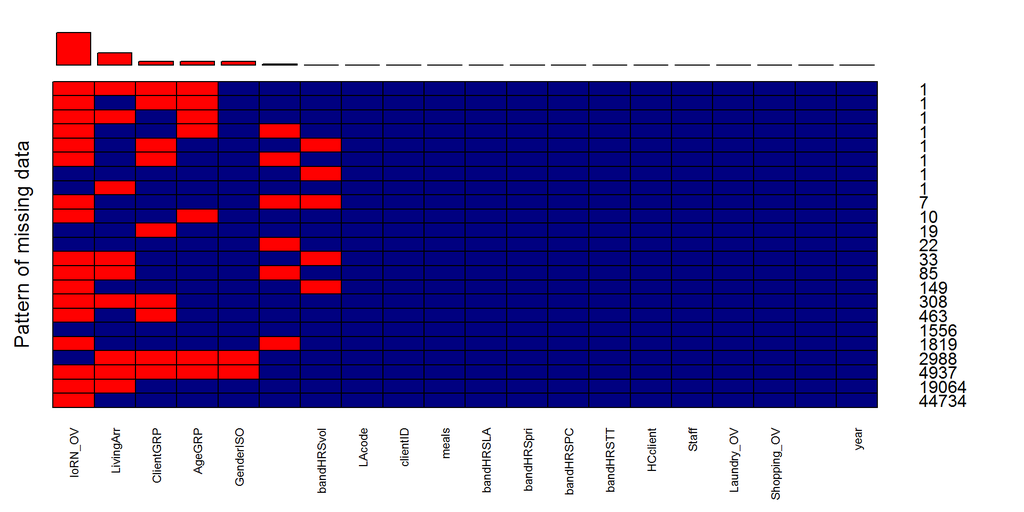

```
##
##  Variables sorted by number of missings:
##           Variable Count
##            IoRN_OV 71615
##          LivingArr 27418
##          ClientGRP  8719
##             AgeGRP  7939
##          GenderISO  7925
##     HousingType_OV  1935
##         bandHRSvol   191
##             LAcode     0
##           clientID     0
##              meals     0
##          bandHRSLA     0
##         bandHRSpri     0
##          bandHRSPC     0
##          bandHRSTT     0
##           HCclient     0
##              Staff     0
##         Laundry_OV     0
##        Shopping_OV     0
##  HousingSupport_OV     0
##               year     0
```

It took me a little while to figure out how to read this plot.

Basically we start at the bottom-right corner and can see 44734 observations. Looking across the plot shows us that these observations are missing the IoRN_OV variable only. Next up 19064 observations are missing IoRN_OV and Living Arr. 4937 obsevrations are missing IoRN_OV, LivingArrm ClientGRP, AgeGRP, and GenderISO etc. etc. It is a very handy plot!

Looking at the bottom 2 numbers shows 63798 of the 76202 observations in 2010 are missing data for IoRN or IoRN and LivingArr only. A further 1556 have no missing data at all.

Given there is a Flag in the data to distinguish homecare from no homecare clients - let’s assess the missingness across these subsets. There are 10687 observations in the No homecare subset and 65515 observations in the home care dataset for 2010.

### 5.1.2 No Home Care

```r
apply(nohmcare_sc10, 2, missing)
```

```
##            LAcode          clientID            AgeGRP         ClientGRP
##              0.00              0.00             74.16             74.16
##         GenderISO             meals         bandHRSLA        bandHRSpri
##             74.16              0.00              0.00              0.00
##        bandHRSvol         bandHRSPC         bandHRSTT          HCclient
##              0.00              0.00              0.00              0.00
##         LivingArr             Staff    HousingType_OV        Laundry_OV
##             84.65              0.00              0.82              0.00
##       Shopping_OV HousingSupport_OV           IoRN_OV              year
##              0.00              0.00             72.04              0.00
```

Clearly a lot more missing data in this subset for AgeGRP, ClientGRPm and GenderISO. In fact exactly the same (rounded) percentages suggesting these are missing across observations. 84% of the 10687 observations have missing data for LivingArr which is probably too high to be be useful. Again IoRN_OV is poorly recorded.

```r
nohmcare_sc10missing <- aggr(nohmcare_sc10, col=c('navyblue','red'), combined = TRUE,
                             numbers=TRUE, prop = FALSE, sortVars=TRUE, labels=names(sc10),
                             cex.axis=.7, gap=3, digits = 2, bars = FALSE,
                             ylab=c("Pattern of missing data"))
```

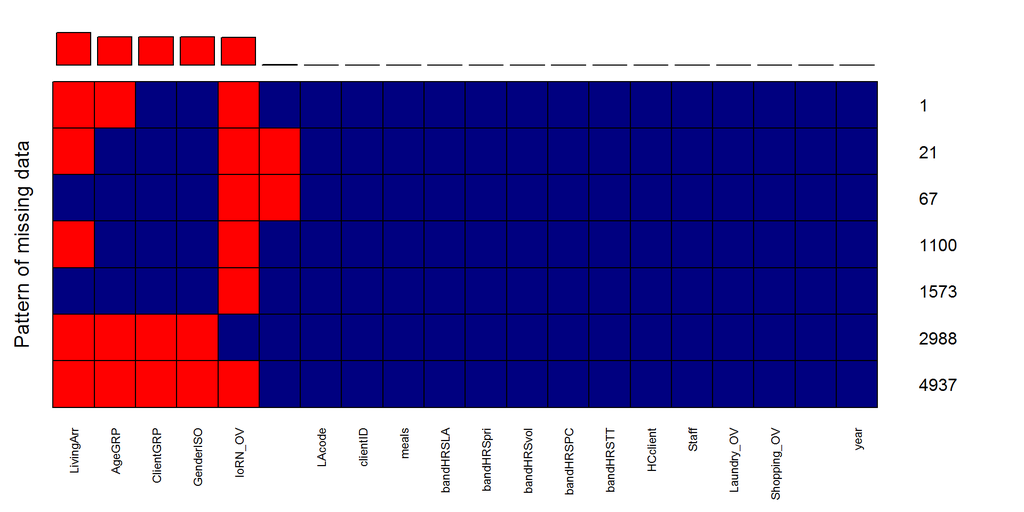

```
##
##  Variables sorted by number of missings:
##           Variable Count
##          LivingArr  9047
##             AgeGRP  7926
##          ClientGRP  7925
##          GenderISO  7925
##            IoRN_OV  7699
##     HousingType_OV    88
##             LAcode     0
##           clientID     0
##              meals     0
##          bandHRSLA     0
##         bandHRSpri     0
##         bandHRSvol     0
##          bandHRSPC     0
##          bandHRSTT     0
##           HCclient     0
##              Staff     0
##         Laundry_OV     0
##        Shopping_OV     0
##  HousingSupport_OV     0
##               year     0
```

The 4937 observations seen in the whole 2010 dataset with missing observations for 5 variables are all in this No home care subset. A further 2988 observations are missing 4 (important) variables. This accounts for 74.16% of the subset data.

### 5.1.3 Home Care

```r
apply(hmcare_sc10, 2, missing)
```

```
##            LAcode          clientID            AgeGRP         ClientGRP
##              0.00              0.00              0.02              1.21
##         GenderISO             meals         bandHRSLA        bandHRSpri
##              0.00              0.00              0.00              0.00
##        bandHRSvol         bandHRSPC         bandHRSTT          HCclient
##              0.29              0.00              0.00              0.00
##         LivingArr             Staff    HousingType_OV        Laundry_OV
##             28.04              0.00              2.82              0.00
##       Shopping_OV HousingSupport_OV           IoRN_OV              year
##              0.00              0.00             97.56              0.00
```

So, of the 65515 observations in the home care subset, we can see that only fractions have missing data for AgeGRP, ClientGRP, and Gender. 28% of this subset has missing data for LivingArr compared to 35% of the total 2010 observations.

```r
hmcare_sc10missing <- aggr(hmcare_sc10, col=c('navyblue','red'), combined = TRUE,
                           numbers=TRUE, prop = FALSE, sortVars=TRUE, labels=names(sc10),
                           cex.axis=.7, gap=3, digits = 2, bars = FALSE,
                           ylab=c("Pattern of missing data"))
```

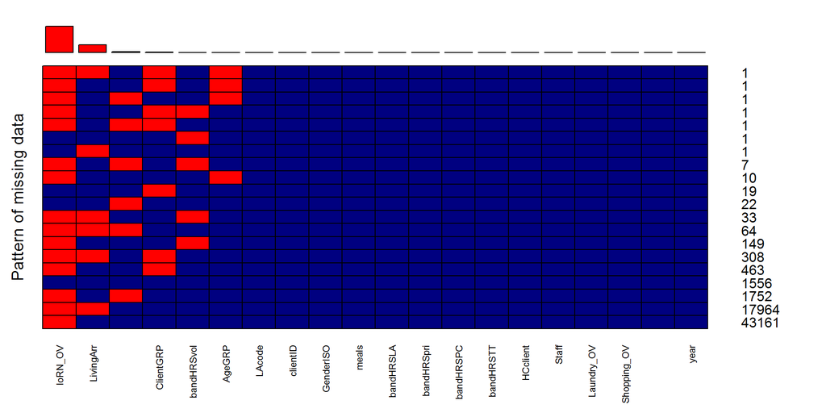

```
##
##  Variables sorted by number of missings:
##           Variable Count
##            IoRN_OV 63916
##          LivingArr 18371
##     HousingType_OV  1847
##          ClientGRP   794
##         bandHRSvol   191
##             AgeGRP    13
##             LAcode     0
##           clientID     0
##          GenderISO     0
##              meals     0
##          bandHRSLA     0
##         bandHRSpri     0
##          bandHRSPC     0
##          bandHRSTT     0
##           HCclient     0
##              Staff     0
##         Laundry_OV     0
##        Shopping_OV     0
##  HousingSupport_OV     0
##               year     0
```

Only 1 observation in the Home Care subset has more than 3 missing variables. 62681 observations have either complete data, are missing IoRN_OV only, or are missing IoRN_OV & LivingArr only. This represents 95.67% of the Home Care subset and is reassuring.

## 5.2 2011

Repeat these analyses for 2011 data.

### 5.2.1 All data

```r
apply(sc11, 2, missing)
```

```
##               LAcode             clientID               AgeGRP
##                 0.00                 0.00                 2.39
##            ClientGRP            GenderISO                meals
##                18.18                 1.65                92.92
##            bandHRSLA           bandHRSpri           bandHRSvol
##                 0.00                 0.00                 0.13
##            bandHRSPC            bandHRSTT             HCclient
##                 0.00                 0.00                 0.00
##   communityalarmonly         telecareonly communityandtelecare
##                 0.00                 0.00                 0.00
##            LivingArr                Staff       HousingType_OV
##                51.17                 0.00                 4.16
##           Laundry_OV          Shopping_OV    HousingSupport_OV
##                 0.00                 0.00                 0.00
##              IoRN_OV                 year
##                94.41                 0.00
```

Missingness across observations:-

```r
sc11missing <- aggr(sc11, col=c('navyblue','red'), combined = TRUE, numbers=TRUE,
                    prop = FALSE, sortVars=TRUE, labels=names(sc11), cex.lab=1.5,
                    cex.axis=0.6, gap=3, digits = 2, bars = FALSE,
                    ylab=c("Pattern"))
```

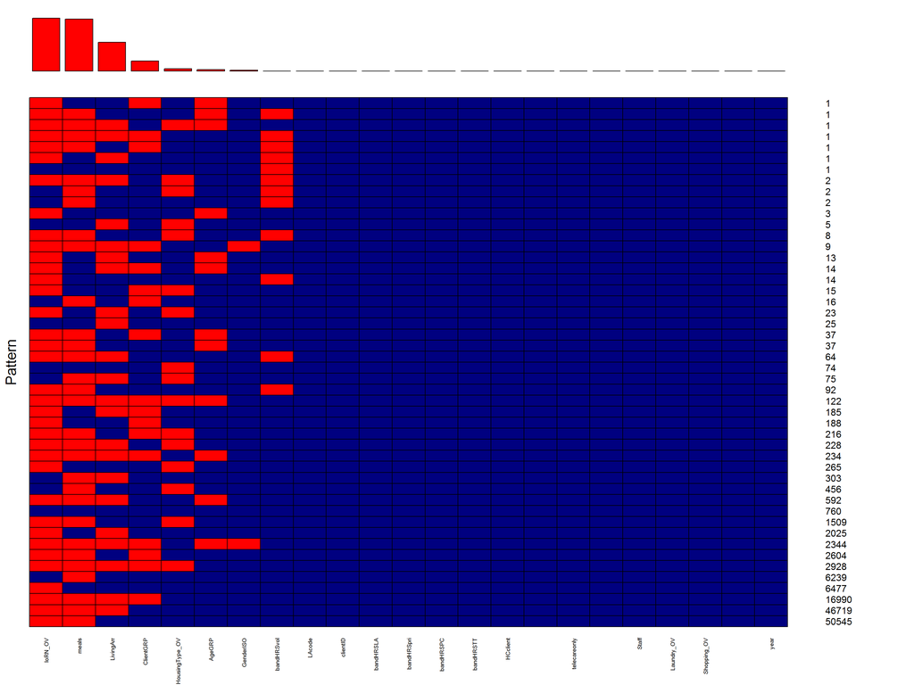

Pattern of Missing Data, 2011

```
##
##  Variables sorted by number of missings:
##              Variable  Count
##               IoRN_OV 134508
##                 meals 132377
##             LivingArr  72903
##             ClientGRP  25905
##        HousingType_OV   5929
##                AgeGRP   3399
##             GenderISO   2353
##            bandHRSvol    189
##                LAcode      0
##              clientID      0
##             bandHRSLA      0
##            bandHRSpri      0
##             bandHRSPC      0
##             bandHRSTT      0
##              HCclient      0
##    communityalarmonly      0
##          telecareonly      0
##  communityandtelecare      0
##                 Staff      0
##            Laundry_OV      0
##           Shopping_OV      0
##     HousingSupport_OV      0
##                  year      0
```

112735 observations have either complete data or varying combinations of missing data for Iorn_OV, meals, and LivingArr. This represents 79.13% of the 2011 dataset.

I’ll now assess the 2011 by the No home care and Home Care subsets.

### 5.2.2 No Home Care

```r
apply(nohmcare_sc11, 2, missing)
```

```
##               LAcode             clientID               AgeGRP
##                 0.00                 0.00                 4.26
##            ClientGRP            GenderISO                meals
##                31.27                 2.95                95.81
##            bandHRSLA           bandHRSpri           bandHRSvol
##                 0.00                 0.00                 0.00
##            bandHRSPC            bandHRSTT             HCclient
##                 0.00                 0.00                 0.00
##   communityalarmonly         telecareonly communityandtelecare
##                 0.00                 0.00                 0.00
##            LivingArr                Staff       HousingType_OV
##                71.65                 0.00                 4.44
##           Laundry_OV          Shopping_OV    HousingSupport_OV
##                 0.00                 0.00                 0.00
##              IoRN_OV                 year
##                98.82                 0.00
```

All the missing data is a higher proportion than in the whole 2011 dataset. We know IoRN and meals are no use but I wonder if almost all the 2011 missing data for the other variables is in this subset….

```r
nohmcare_sc11missing <- aggr(nohmcare_sc11, col=c('navyblue','red'), combined = TRUE,
                             numbers=TRUE, prop = FALSE, sortVars=TRUE,
                             labels=names(nohmcare_sc11), cex.lab=1.5, cex.axis=0.6,
                             gap=3, digits = 2, bars = FALSE, ylab=c("Pattern"))
```

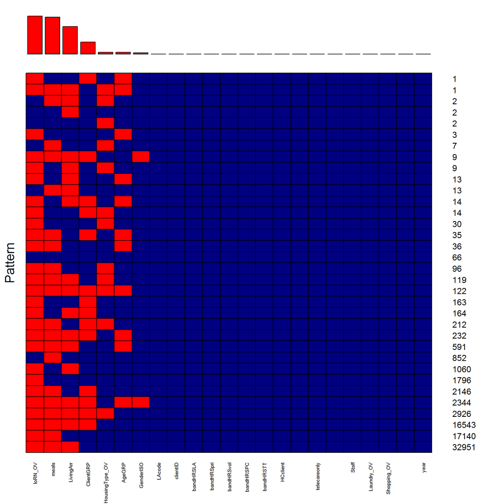

Pattern of missing data. No Home care subset, 2011

```
##
##  Variables sorted by number of missings:
##              Variable Count
##               IoRN_OV 78770
##                 meals 76377
##             LivingArr 57115
##             ClientGRP 24925
##        HousingType_OV  3540
##                AgeGRP  3392
##             GenderISO  2353
##                LAcode     0
##              clientID     0
##             bandHRSLA     0
##            bandHRSpri     0
##            bandHRSvol     0
##             bandHRSPC     0
##             bandHRSTT     0
##              HCclient     0
##    communityalarmonly     0
##          telecareonly     0
##  communityandtelecare     0
##                 Staff     0
##            Laundry_OV     0
##           Shopping_OV     0
##     HousingSupport_OV     0
##                  year     0
```

53865 observations have either complete data or varying combinations of missing data for Iorn_OV, meals, and LivingArr. This represents 67.57% of the 2011 No Home Care subset.

### 5.2.3 Home Care

```r
apply(hmcare_sc11, 2, missing)
```

```
##               LAcode             clientID               AgeGRP
##                 0.00                 0.00                 0.01
##            ClientGRP            GenderISO                meals
##                 1.56                 0.00                89.24
##            bandHRSLA           bandHRSpri           bandHRSvol
##                 0.00                 0.00                 0.30
##            bandHRSPC            bandHRSTT             HCclient
##                 0.00                 0.00                 0.00
##   communityalarmonly         telecareonly communityandtelecare
##                 0.00                 0.00                 0.00
##            LivingArr                Staff       HousingType_OV
##                25.16                 0.00                 3.81
##           Laundry_OV          Shopping_OV    HousingSupport_OV
##                 0.00                 0.00                 0.00
##              IoRN_OV                 year
##                88.82                 0.00
```

So next to no missing data for our Home care subset apart from our usual villans of meals and IoRN. LivingArr has a respectable (for admin data) missingness proportion of 25%.

```r
hmcare_sc11missing <- aggr(hmcare_sc11, col=c('navyblue','red'), combined = TRUE,
                           numbers=TRUE, prop = FALSE, sortVars=TRUE,
                           labels=names(hmcare_sc11), cex.axis=.7, gap=3, digits = 2,
                           bars = FALSE, lab=c("Pattern of missing data"))
```

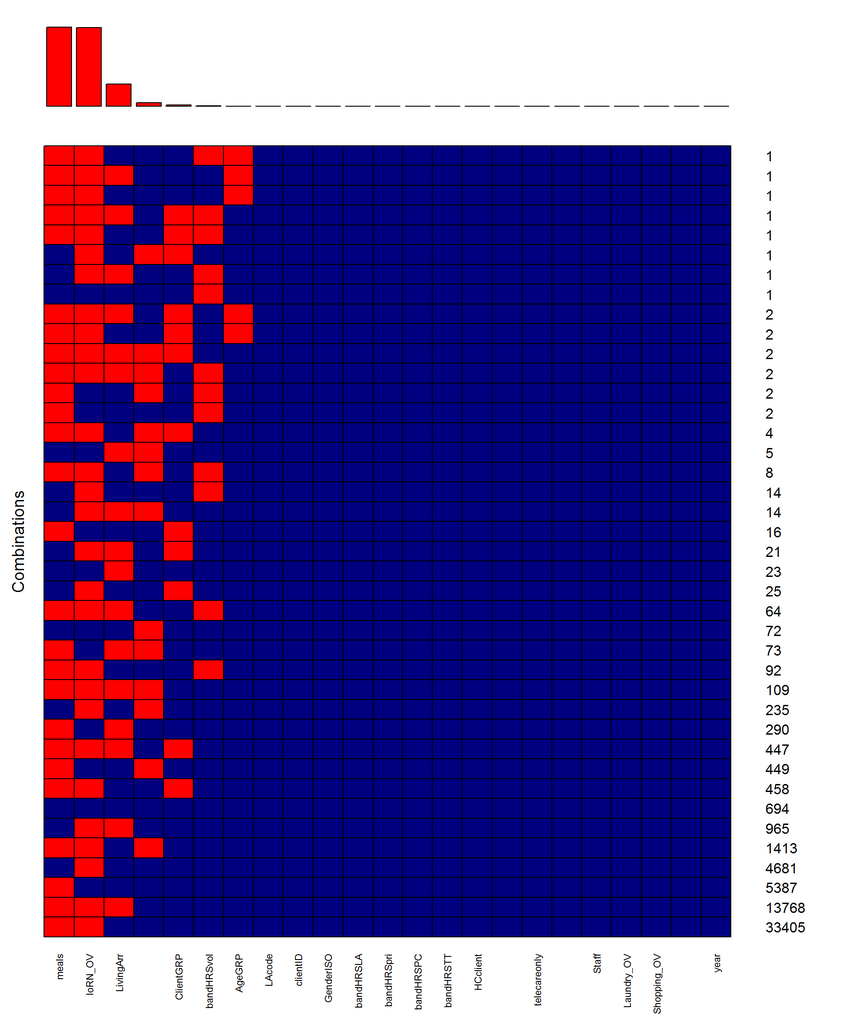

```
##
##  Variables sorted by number of missings:
##              Variable Count
##                 meals 56000
##               IoRN_OV 55738
##             LivingArr 15788
##        HousingType_OV  2389
##             ClientGRP   980
##            bandHRSvol   189
##                AgeGRP     7
##                LAcode     0
##              clientID     0
##             GenderISO     0
##             bandHRSLA     0
##            bandHRSpri     0
##             bandHRSPC     0
##             bandHRSTT     0
##              HCclient     0
##    communityalarmonly     0
##          telecareonly     0
##  communityandtelecare     0
##                 Staff     0
##            Laundry_OV     0
##           Shopping_OV     0
##     HousingSupport_OV     0
##                  year     0
```

59213 observations have either complete data or varying combinations of missing data for Iorn_OV, meals, and LivingArr. This represents 94.36% of the 2011 Home Care subset.

## 5.3 2012

### 5.3.1 All data

```r
apply(sc12, 2, missing)
```

```
##               LAcode             clientID               AgeGRP
##                 0.00                 0.00                 0.95
##            ClientGRP            GenderISO                meals
##                12.16                 0.01                93.18
##             newhours            bandHRSLA           bandHRSpri
##                55.91                 0.00                 0.00
##           bandHRSvol            bandHRSPC            bandHRSTT
##                 0.15                 0.00                 0.00
##             HCclient   communityalarmonly         telecareonly
##                 0.00                 0.00                 0.00
## communityandtelecare            LivingArr                Staff
##                 0.00                41.91                 0.00
##       HousingType_OV           Laundry_OV          Shopping_OV
##                 3.30                 0.00                 0.00
##    HousingSupport_OV              IoRN_OV                 year
##                 0.00                93.61                 0.00
```

I can also visualise the missingness across observations.

```r
sc12missing <- aggr(sc12, col=c('navyblue','red'), combined = TRUE, numbers=TRUE,
                    prop = FALSE, sortVars=TRUE, labels=names(sc12), cex.lab=1.5,
                    cex.axis=0.6, gap=3, digits = 2, bars = FALSE,
                    ylab=c("Pattern"))
```

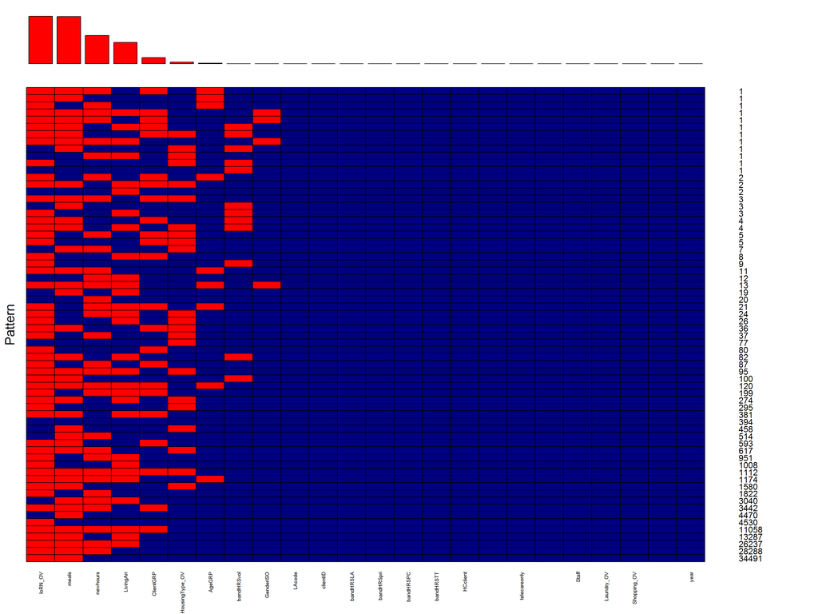

Pattern of Missing Data, 2012

```
##
##  Variables sorted by number of missings:
##              Variable  Count
##               IoRN_OV 132125
##                 meals 131523
##              newhours  78917
##             LivingArr  59156
##             ClientGRP  17163
##        HousingType_OV   4661
##                AgeGRP   1344
##            bandHRSvol    210
##             GenderISO     16
##                LAcode      0
##              clientID      0
##             bandHRSLA      0
##            bandHRSpri      0
##             bandHRSPC      0
##             bandHRSTT      0
##              HCclient      0
##    communityalarmonly      0
##          telecareonly      0
##  communityandtelecare      0
##                 Staff      0
##            Laundry_OV      0
##           Shopping_OV      0
##     HousingSupport_OV      0
##                  year      0
```

119032 observations have either complete data or varying combinations of missing data for Iorn_OV, meals, newhours, and LivingArr. This represents 84.33% of the 2012 dataset.

I’ll now assess the 2012 data by the No home care and Home Care subsets.

### 5.3.2 No Home Care

```r
apply(nohmcare_sc12, 2, missing)
```

```
##               LAcode             clientID               AgeGRP
##                 0.00                 0.00                 1.70
##            ClientGRP            GenderISO                meals
##                20.34                 0.02                95.97
##             newhours            bandHRSLA           bandHRSpri
##               100.00                 0.00                 0.00
##           bandHRSvol            bandHRSPC            bandHRSTT
##                 0.00                 0.00                 0.00
##             HCclient   communityalarmonly         telecareonly
##                 0.00                 0.00                 0.00
## communityandtelecare            LivingArr                Staff
##                 0.00                55.83                 0.00
##       HousingType_OV           Laundry_OV          Shopping_OV
##                 2.41                 0.00                 0.00
##    HousingSupport_OV              IoRN_OV                 year
##                 0.00                95.45                 0.00
```

Again proportions of missing data are higher in this subset than in the whole dataset - even though they are pretty small numbers. 100% newhours missing data is here - which makes perdect sense. If somebody isn’t getting home care at all then they can;t get new hours! Potentially 100% complete in the Home care subset.

```r
nohmcare_sc12missing <- aggr(nohmcare_sc12, col=c('navyblue','red'), combined = TRUE,
                             numbers=TRUE, prop = FALSE, sortVars=TRUE, labels=names(sc12),
                             cex.axis=.7, gap=3, digits = 2, bars = FALSE,
                             ylab=c("Pattern of missing data"))
```

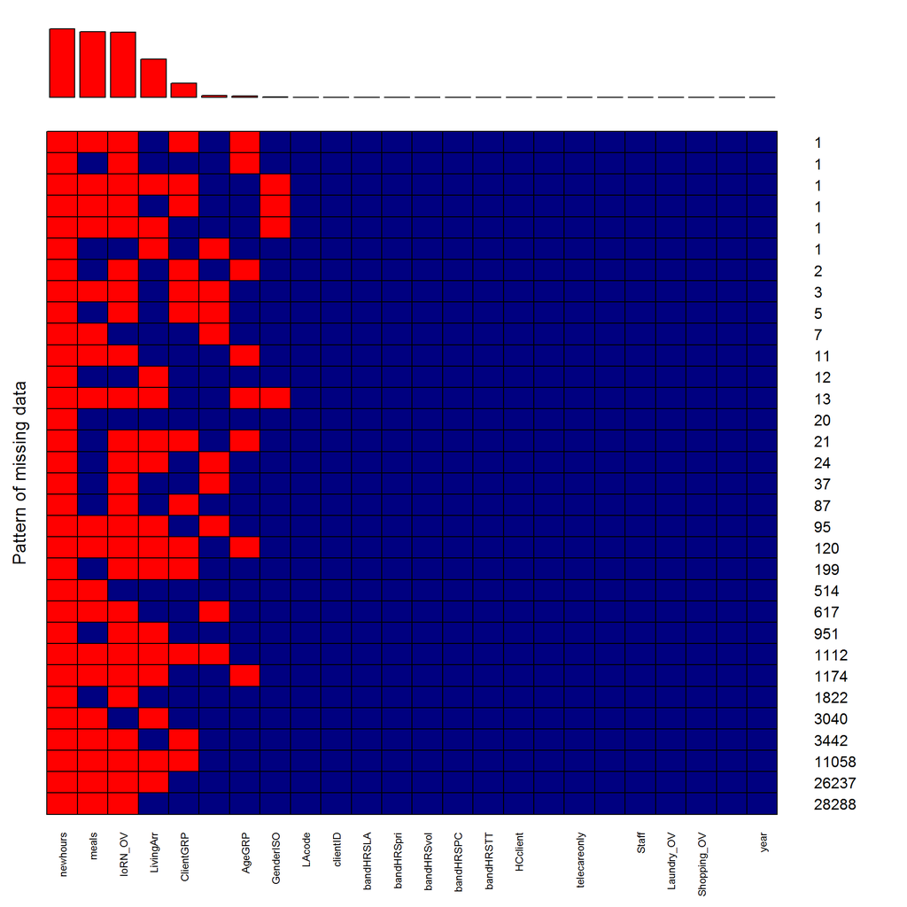

Pattern of Missing Data, No Home Care Subset, 2012

```
##
##  Variables sorted by number of missings:
##              Variable Count
##              newhours 78917
##                 meals 75735
##               IoRN_OV 75323
##             LivingArr 44059
##             ClientGRP 16052
##        HousingType_OV  1901
##                AgeGRP  1343
##             GenderISO    16
##                LAcode     0
##              clientID     0
##             bandHRSLA     0
##            bandHRSpri     0
##            bandHRSvol     0
##             bandHRSPC     0
##             bandHRSTT     0
##              HCclient     0
##    communityalarmonly     0
##          telecareonly     0
##  communityandtelecare     0
##                 Staff     0
##            Laundry_OV     0
##           Shopping_OV     0
##     HousingSupport_OV     0
##                  year     0
```

60884 observations have varying combinations of missing data for newhours, Iorn_OV, meals, and LivingArr. This represents 77.15% of the 2012 No Home Care subset.

### 5.3.3 Home Care

```r
apply(hmcare_sc12, 2, missing)
```

```
##               LAcode             clientID               AgeGRP
##                 0.00                 0.00                 0.00
##            ClientGRP            GenderISO                meals
##                 1.79                 0.00                89.65
##             newhours            bandHRSLA           bandHRSpri
##                 0.00                 0.00                 0.00
##           bandHRSvol            bandHRSPC            bandHRSTT
##                 0.34                 0.00                 0.00
##             HCclient   communityalarmonly         telecareonly
##                 0.00                 0.00                 0.00
## communityandtelecare            LivingArr                Staff
##                 0.00                24.26                 0.00
##       HousingType_OV           Laundry_OV          Shopping_OV
##                 4.44                 0.00                 0.00
##    HousingSupport_OV              IoRN_OV                 year
##                 0.00                91.28                 0.00
```

Again - next to no missingness for our main variables apart from IoRN and meals. New hours is indeed 100% complete in this subset (as it should be).

```r
hmcare_sc12missing <- aggr(hmcare_sc12, col=c('navyblue','red'), combined = TRUE,
                           numbers=TRUE, prop = FALSE, sortVars=TRUE,
                           labels=names(hmcare_sc12),
                           cex.axis=.7, gap=3, digits = 2, bars = FALSE,
                           ylab=c("Pattern of missing data"))
```

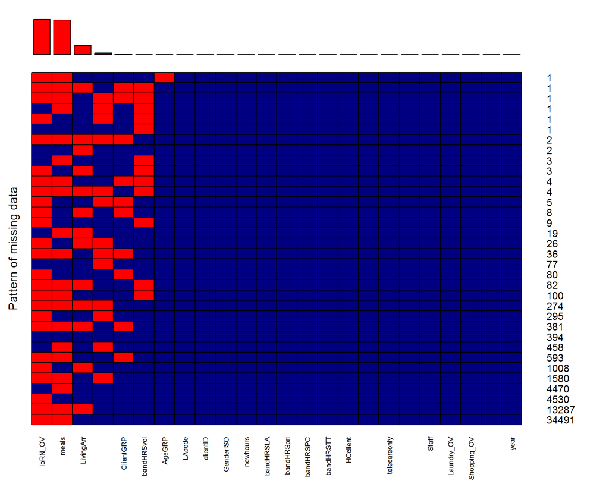

```
##
##  Variables sorted by number of missings:
##              Variable Count
##               IoRN_OV 56802
##                 meals 55788
##             LivingArr 15097
##        HousingType_OV  2760
##             ClientGRP  1111
##            bandHRSvol   210
##                AgeGRP     1
##                LAcode     0
##              clientID     0
##             GenderISO     0
##              newhours     0
##             bandHRSLA     0
##            bandHRSpri     0
##             bandHRSPC     0
##             bandHRSTT     0
##              HCclient     0
##    communityalarmonly     0
##          telecareonly     0
##  communityandtelecare     0
##                 Staff     0
##            Laundry_OV     0
##           Shopping_OV     0
##     HousingSupport_OV     0
##                  year     0
```

58201 observations have varying combinations of missing data for Iorn_OV, meals, and LivingArr. This represents 93.53% of the 2012 Home Care subset.

## 5.4 Conclusions

- Across all 3 years the majority of missing data is in the subset of individuals that do not receive home care services but *only* receive telecare or some other form of service such as Laundry or Shopping.
- IoRN_OV data is barely completed in any year and is of little use in any analysis.
- Meals data shows high levels of missingness in 2011 and 2012. It is impossible to tell whether this data is missing or refelcts “No Meals” as in the 2010 dataset. SG reports on the Social Care Survey do tend to say something along the lines of “Meals data has proved difficult for LAs to capture” which suggests to me it is not a reliable variable.
- Of the other variables LivingArr has approx 25% missing data. Further analysis required to see if this is Missing at Random or if there is something more structural going on.
- Given it has good levels of complete data I will provide more detailed descriptive analaysis of the Home Care subset first.

```
##  setting  value
##  version  R version 3.3.2 (2016-10-31)
##  system   x86_64, mingw32
##  ui       RTerm
##  language (EN)
##  collate  English_United Kingdom.1252
##  tz       Europe/London
##  date     2017-02-24
```

```
## Packages ------------------------------------------------------------------
```

```
##  package      * version date       source
##  assertthat     0.1     2013-12-06 CRAN (R 3.3.2)
##  backports      1.0.5   2017-01-18 CRAN (R 3.3.2)
##  boot           1.3-18  2016-02-23 CRAN (R 3.3.2)
##  car            2.1-4   2016-12-02 CRAN (R 3.3.2)
##  class          7.3-14  2015-08-30 CRAN (R 3.3.2)
##  codetools      0.2-15  2016-10-05 CRAN (R 3.3.2)
##  colorspace   * 1.3-2   2016-12-14 CRAN (R 3.3.2)
##  data.table   * 1.10.4  2017-02-01 CRAN (R 3.3.2)
##  DBI            0.5-1   2016-09-10 CRAN (R 3.3.2)
##  DEoptimR       1.0-8   2016-11-19 CRAN (R 3.3.2)
##  devtools       1.12.0  2016-06-24 CRAN (R 3.3.2)
##  digest         0.6.12  2017-01-27 CRAN (R 3.3.2)
##  dplyr        * 0.5.0   2016-06-24 CRAN (R 3.3.2)
##  e1071          1.6-8   2017-02-02 CRAN (R 3.3.2)
##  evaluate       0.10    2016-10-11 CRAN (R 3.3.2)
##  htmltools      0.3.5   2016-03-21 CRAN (R 3.3.2)
##  knitr          1.15.1  2016-11-22 CRAN (R 3.3.2)
##  laeken         0.4.6   2014-08-19 CRAN (R 3.3.2)
##  lattice        0.20-34 2016-09-06 CRAN (R 3.3.2)
##  lazyeval       0.2.0   2016-06-12 CRAN (R 3.3.2)
##  lme4           1.1-12  2016-04-16 CRAN (R 3.3.2)
##  lmtest         0.9-35  2017-02-11 CRAN (R 3.3.2)
##  magrittr       1.5     2014-11-22 CRAN (R 3.3.2)
##  MASS           7.3-45  2016-04-21 CRAN (R 3.3.2)
##  Matrix         1.2-7.1 2016-09-01 CRAN (R 3.3.2)
##  MatrixModels   0.4-1   2015-08-22 CRAN (R 3.3.2)
##  memoise        1.0.0   2016-01-29 CRAN (R 3.3.2)
##  mgcv           1.8-15  2016-09-14 CRAN (R 3.3.2)
##  mice         * 2.30    2017-02-18 CRAN (R 3.3.2)
##  minqa          1.2.4   2014-10-09 CRAN (R 3.3.2)
##  nlme           3.1-128 2016-05-10 CRAN (R 3.3.2)
##  nloptr         1.0.4   2014-08-04 CRAN (R 3.3.2)
##  nnet           7.3-12  2016-02-02 CRAN (R 3.3.2)
##  pbkrtest       0.4-6   2016-01-27 CRAN (R 3.3.2)
##  quantreg       5.29    2016-09-04 CRAN (R 3.3.2)
##  R6             2.2.0   2016-10-05 CRAN (R 3.3.2)
##  Rcpp           0.12.9  2017-01-14 CRAN (R 3.3.2)
##  rmarkdown      1.3     2016-12-21 CRAN (R 3.3.2)
##  robustbase     0.92-7  2016-12-09 CRAN (R 3.3.2)
##  rpart          4.1-10  2015-06-29 CRAN (R 3.3.2)
##  rprojroot      1.2     2017-01-16 CRAN (R 3.3.2)
##  sp             1.2-4   2016-12-22 CRAN (R 3.3.2)
##  SparseM        1.74    2016-11-10 CRAN (R 3.3.2)
##  stringi        1.1.2   2016-10-01 CRAN (R 3.3.2)
##  stringr        1.1.0   2016-08-19 CRAN (R 3.3.2)
##  survival       2.39-5  2016-06-26 CRAN (R 3.3.2)
##  tibble         1.2     2016-08-26 CRAN (R 3.3.2)
##  vcd            1.4-3   2016-09-17 CRAN (R 3.3.2)
##  VIM          * 4.6.0   2016-10-17 CRAN (R 3.3.2)
##  withr          1.0.2   2016-06-20 CRAN (R 3.3.2)
##  yaml           2.1.14  2016-11-12 CRAN (R 3.3.2)
##  zoo            1.7-14  2016-12-16 CRAN (R 3.3.2)
```